# SOM, RF report

# 1 **SOM BIÓTICO:**

## 1.1 Treinamento e Contagem

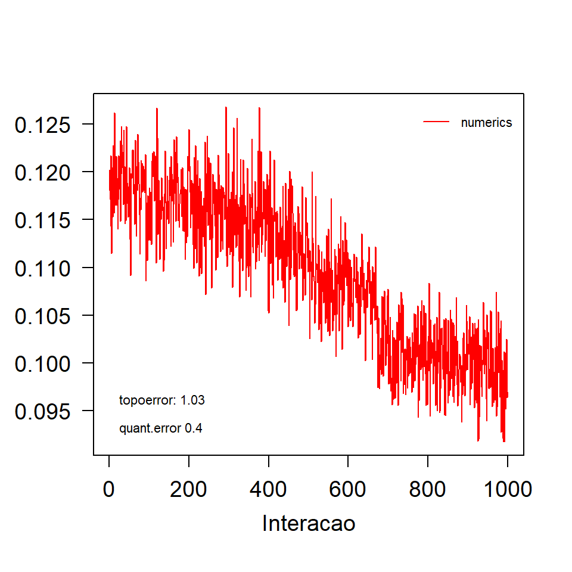

**Figura 1.2a - Processo de Treinamento.**

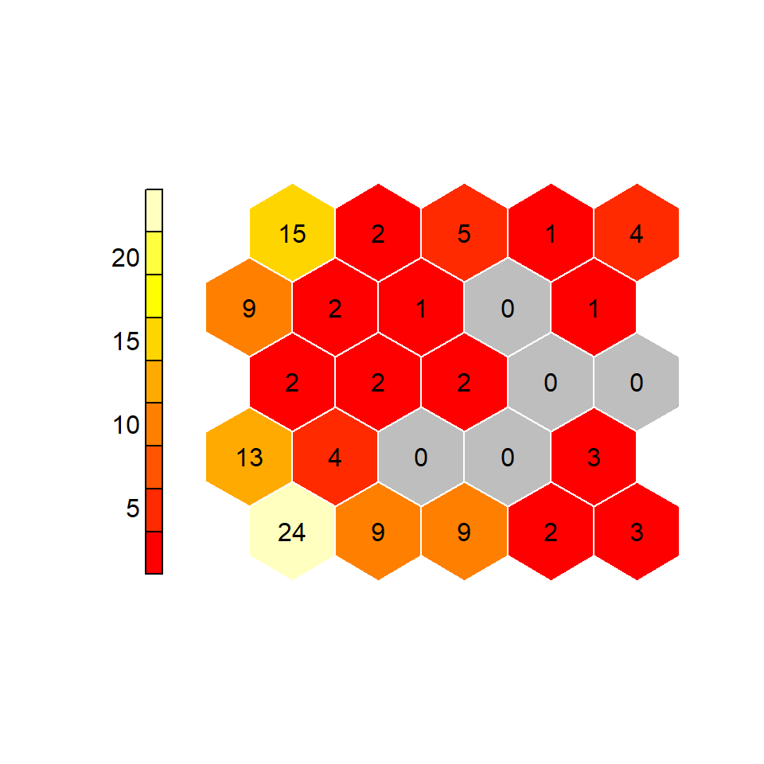

**Figura 1.2b - Contagem.** Contagem de instâncias por célula.

## 1.2 SOMs - Correlações das variáveis influentes e BMU interpolado

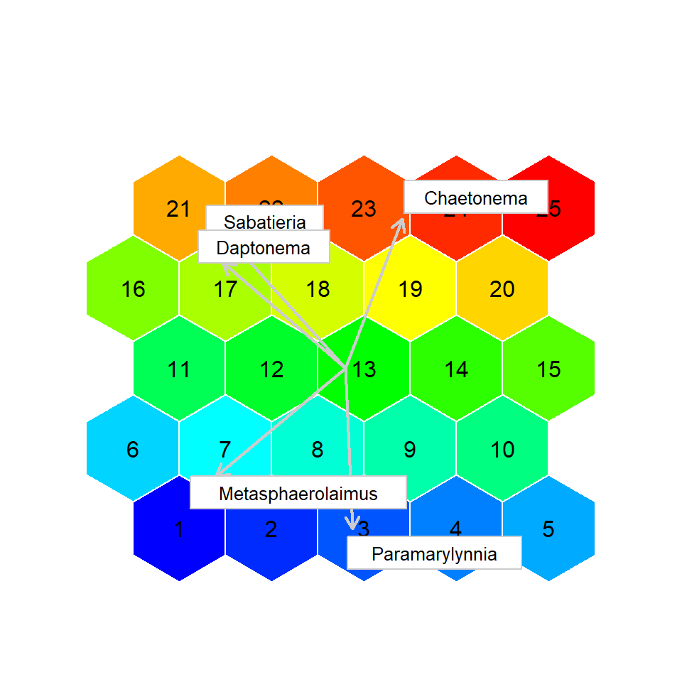

**Figura 1.3a - Variáveis influentes.** Variáveis que induziram os maiores contrastes entre as células do mapa. As setas indicam a direção e a força da correlação entre as variáveis e as células. Os números indicam os rótulos do neurônios (NeuID).

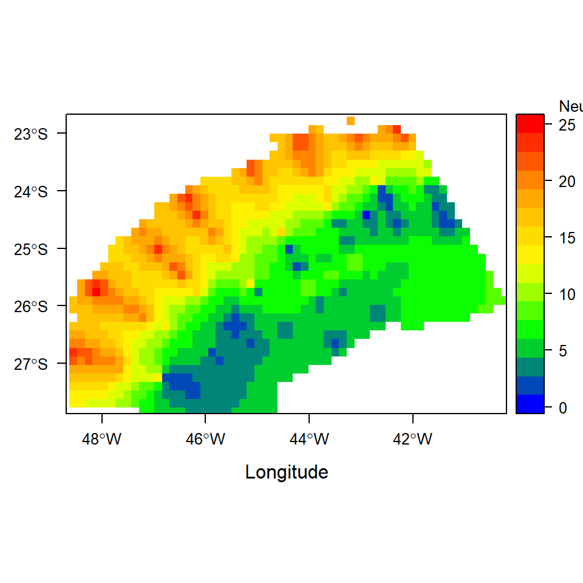

**Figura 1.3b - Interpolação dos resultados do SOM na Bacia de Santos** . A interpolação é baseada na classificação de cada amostra ao longo da rede de nerônios (BMU - ’best unit matching".)

## 1.3 Indicadores SOM

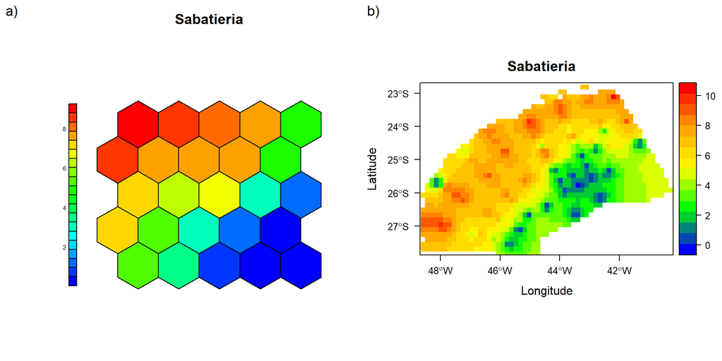

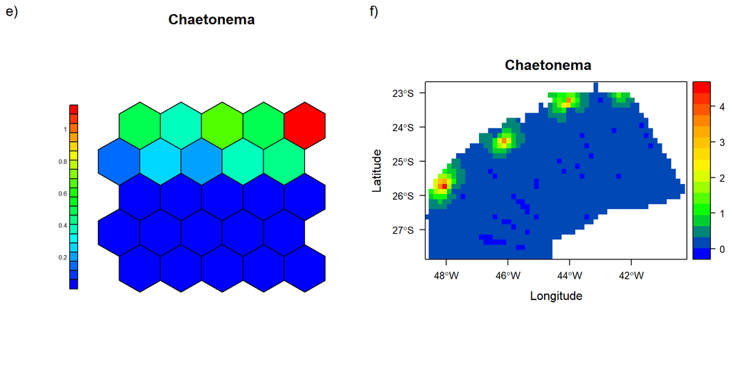

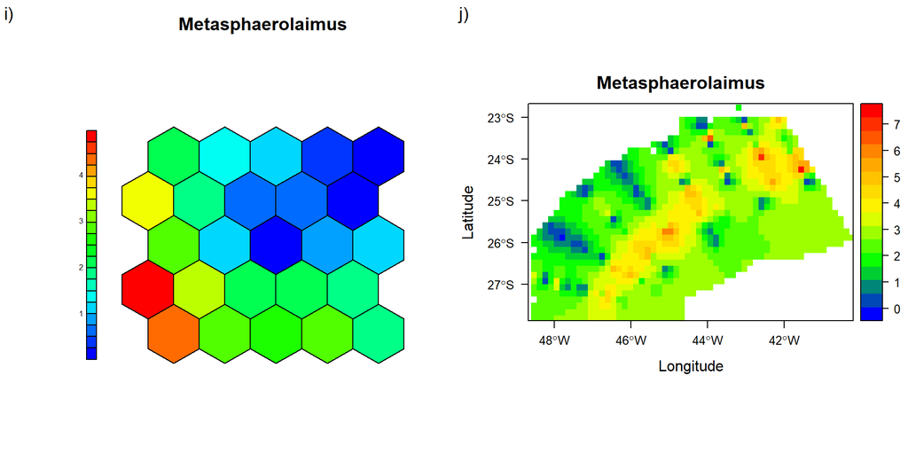

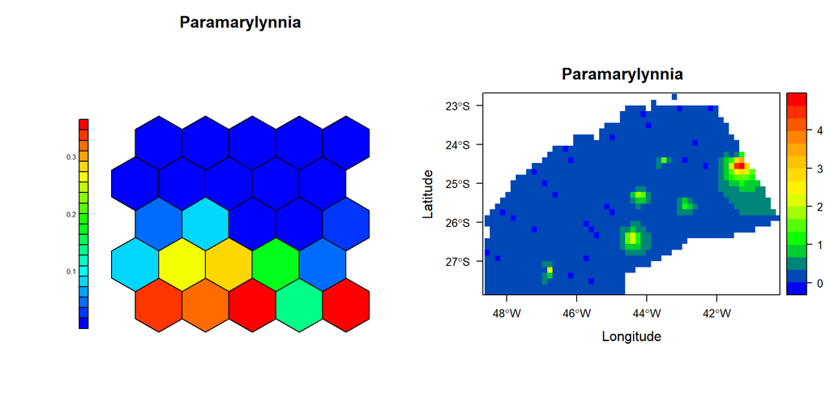

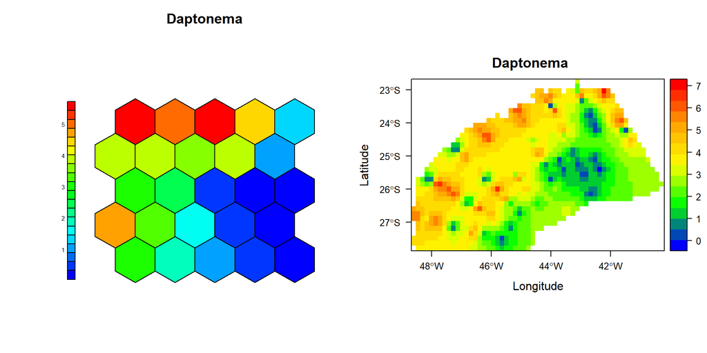

**Figura 1.4. Indicadores SOM** Distribuição das variáveis ao longo do mapa de neurônios (painéis da esquerda) e sua respecitiva distribuição ao longo da Bacia de Santos (painéis da direita).

## 1.4 Análise de Agrupamento

A regra da maioria é usada para identificar o melhor número de clusters. Pacote [`NBclust`](https://www.jstatsoft.org/index.php/jss/article/view/v061i06/v61i06.pdf.)

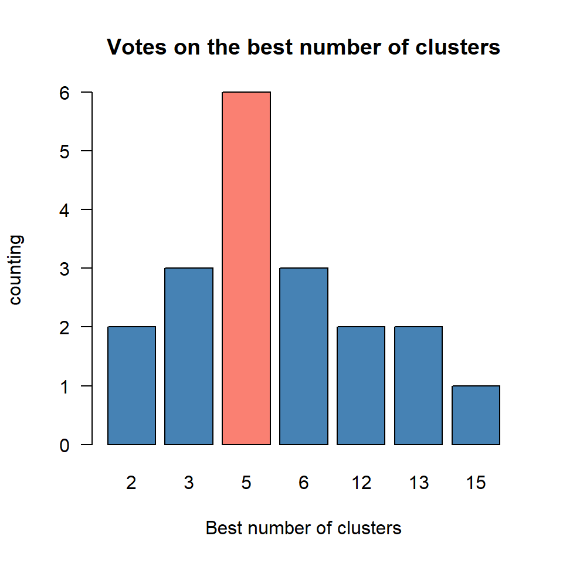

**Figura 1.5a - Número de agrupamentos.** Votos sobre o número ideal de agrupamentos.

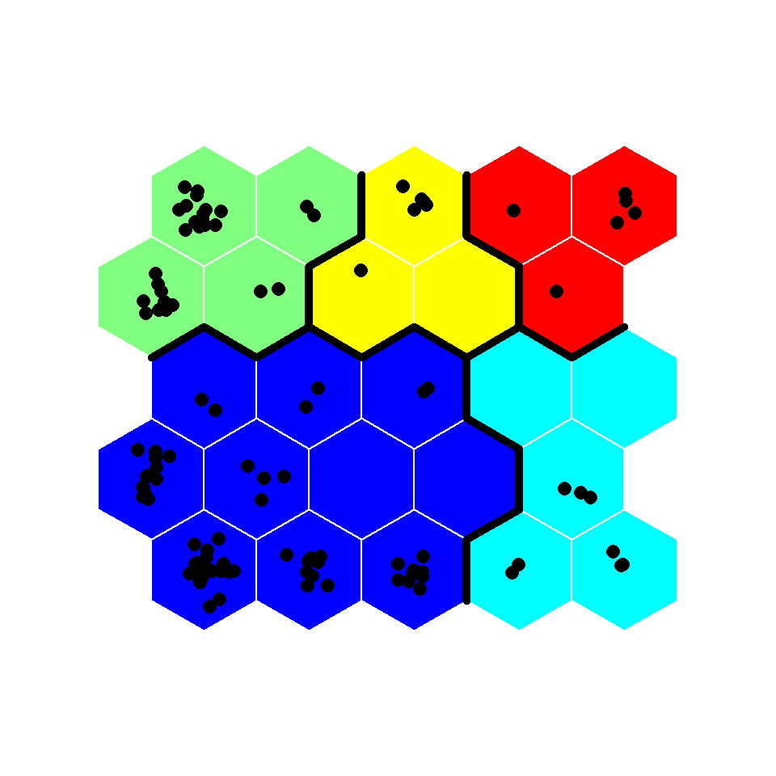

**Figura 1.5b - Agrupamentos dos neurônios.**

## 1.5 Mapa dos habitats

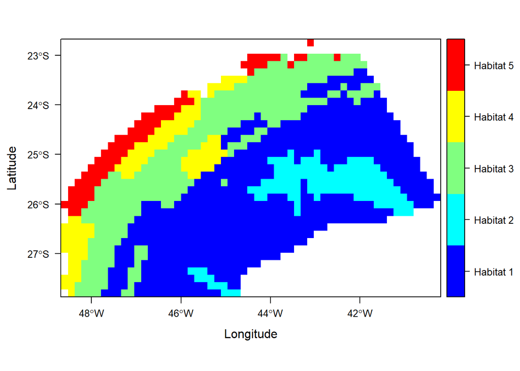

**Figura 1.6 - Habitats.** Interpolação dos Habitats previstos pelo SOM.

## 1.6 Índices univariados por habitat

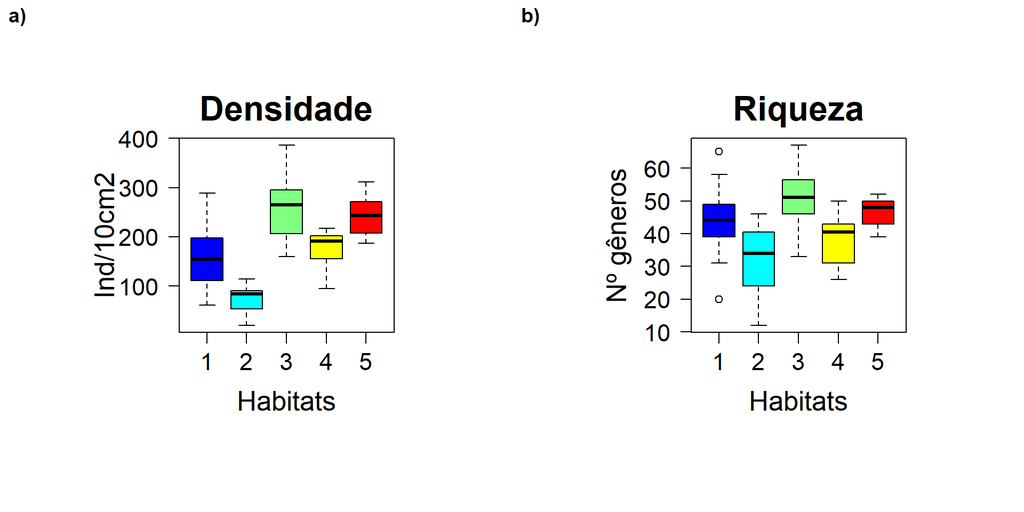

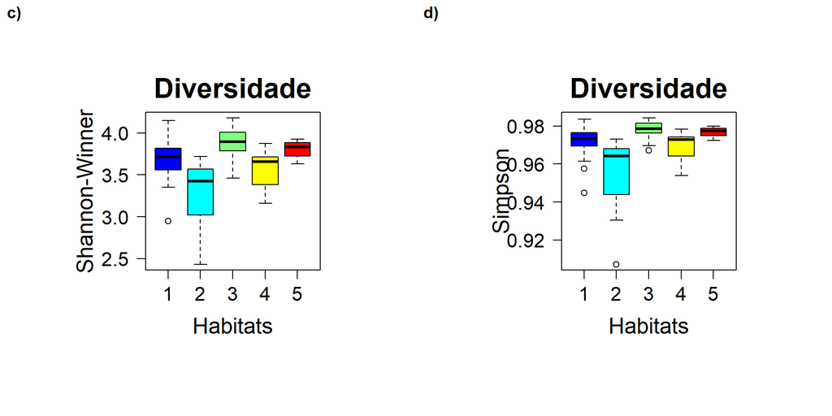

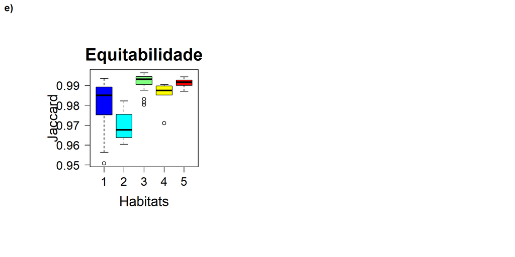

**Figura 1.7 - Índices Univariados** Densidade (a), riqueza (b), diversidade de Shannown-Winner e Simpson (c e d) e equitabilidade.

# 2 **Random Forest**

## 2.1 Matriz de Confusão e Iimportância das variáveis

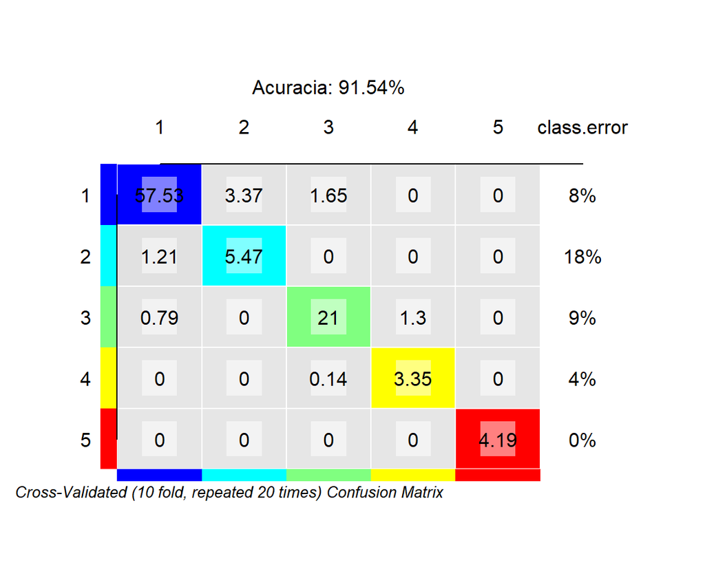

**Figura 2.1a - Matriz de Confusão**

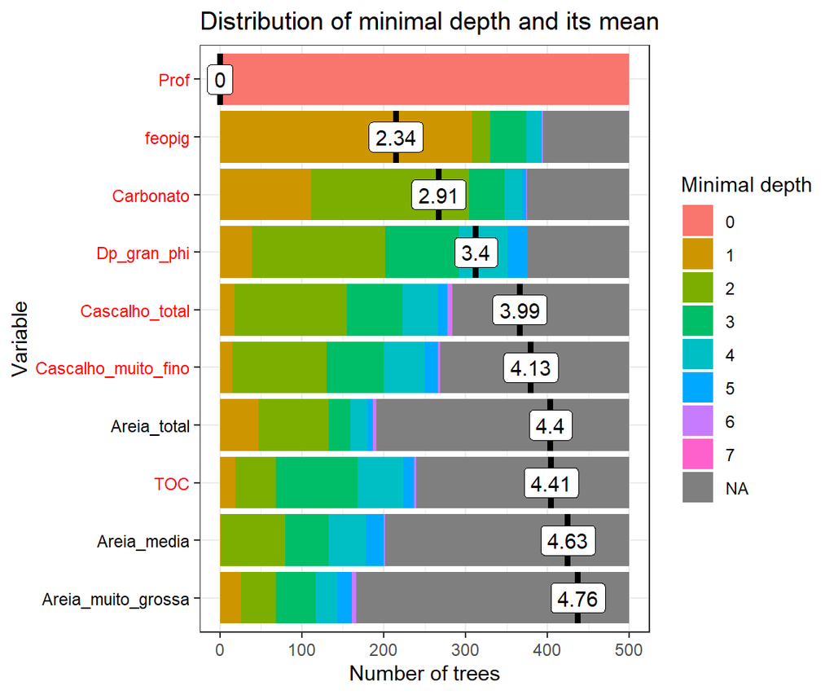

**Figura 2.1b - Distribuição da profundidade mínima entre as árvores da floresta -** A profundidade mínima de uma variável em uma árvore é igual à profundidade do nó que se divide nessa variável e é o mais próximo da raiz da árvore. Se for baixo, muitas observações são divididas em grupos com base nesta variável. Variáveis significativas são exibidas em vermelho (p<0.05). Este teste nos diz se o número observado de sucessos (número de nós em que cada variável foi usado para divisão) excede o número teórico de sucessos se eles fossem aleatórios.

## 2.2 Importância multivariada

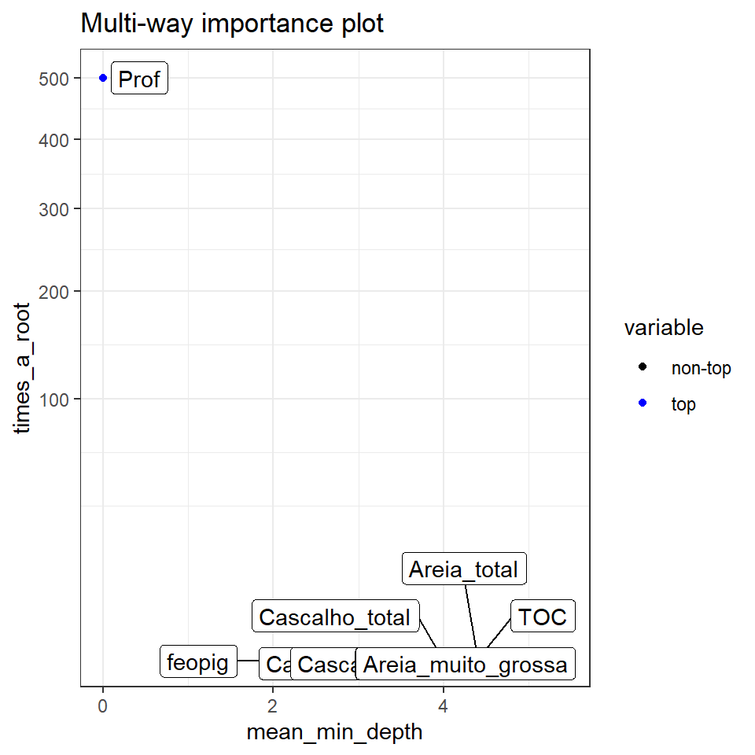

**Figura 2.2a - Importância multivariada** Este gráfico concentra-se em três medidas de importância derivadas da estrutura das árvores na floresta: (a) profundidade média da primeira divisão na variável, (b) número de árvores em que a raiz é dividida na variável e, (c) o número total de nós na floresta que se dividem nessa variável.

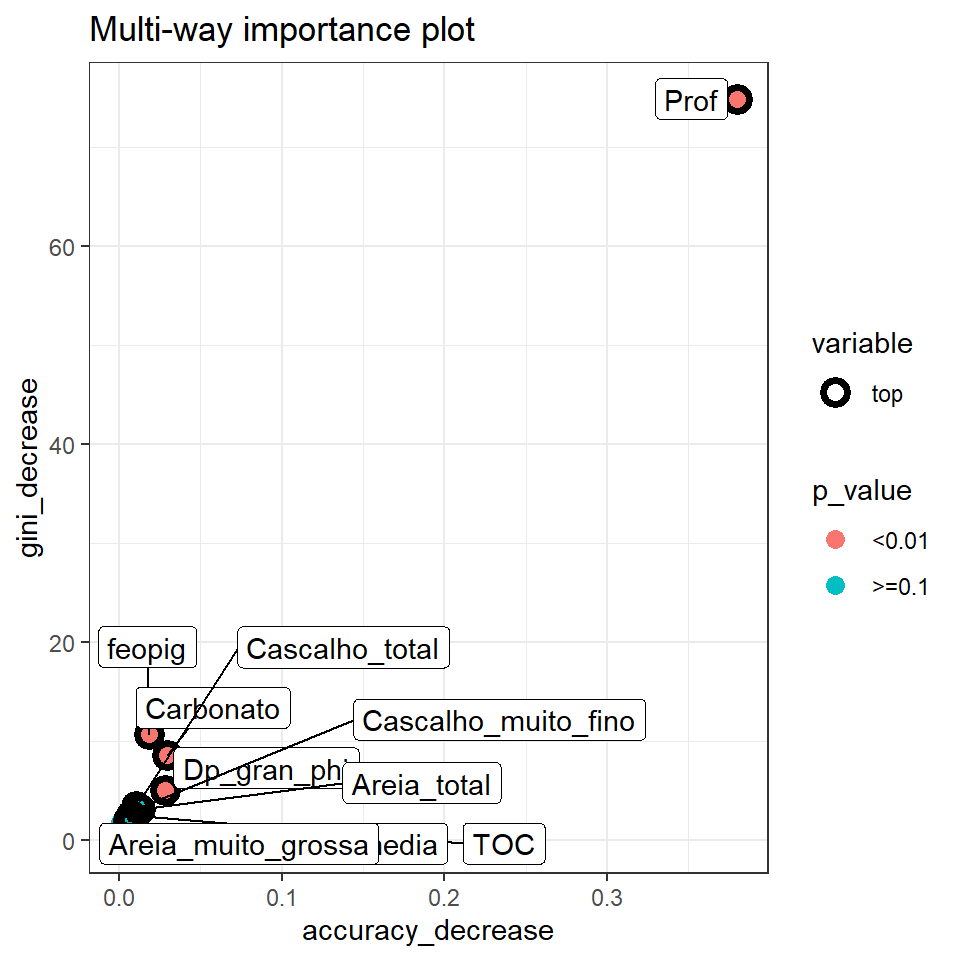

**Figura 2.2b - Importância multivariada**. Este gráfico mostra as medidas de importância que derivam do papel que uma variável desempenha na previsão: accuracy_decrease e gini_decrease mais informações adicionais sobre o valor p. Se uma variável é significativa significa que a variável é usada para dividir com mais frequência do que seria o caso se a seleção fosse aleatória.

## 2.3 Indicadores Random Forest

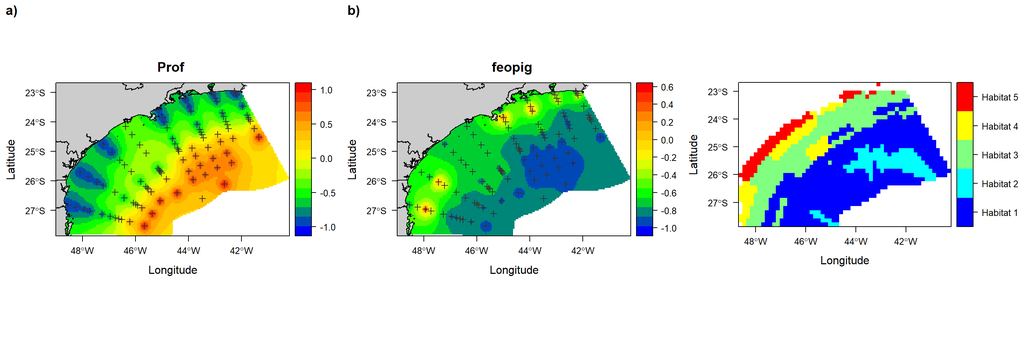

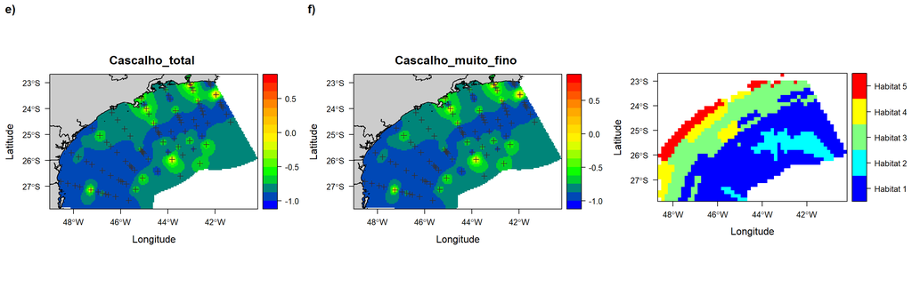